# Tutorial for vulnerability calculation (6 archipelagos)

Clara Marino

2024-12-20

# Set up

### Load packages

Note that all scripts use the native R pipe to not attach dplyr and tidyverse packages.

```r
# clean working environment
rm(list=ls())
#load the only attached package
library(ggplot2)
```

### Set colors of archipelagos for the plots

```r
# set colors
archip_col <-  c(
  "Galapagos Islands" = "#4DAF4A",
  "Canary Islands" = "#377EB8",
  "Azores"="#FF7F00",
  "Mascarene Islands" = "#984EA3",
  "Hawaii" = "#E41A1C",
  "Tristan da Cunha Islands" = "#B15928")
```

### Load custom functions

Custom functions were designed to compute E, S, AC, and final VU based on previously collected markers. They are not yet properly documented and have a lot of parameters by default adapted to this study, but they can be used for any studies that would aim as computing VU based on multiple components. The normalization method of the markers, the markers to include, as well as the final method of calculation of VU can be modified.

```r
source("R/Calculate_components_VU_FUN.R")
```

### Load data

```r
# load data frame in final format
data_all <- readRDS("outputs/30_all_VU_components_45_isl_266_BM_sp.rds")
# load island information and polygons
isl <- readRDS("data/derived-data/01_shp_45_major_isl_clean.rds")

str(data_all)
```

```
## 'data.frame':    1362 obs. of  26 variables:
##  $ ID              : num  7725 7725 7725 7725 7725 ...
##  $ Archip          : chr  "Tristan da Cunha Islands" "Tristan da Cunha Islands" "Tristan da Cunha Islands" "Tristan da Cunha Islands" ...
##  $ Island          : chr  "Nightingale Island" "Nightingale Island" "Nightingale Island" "Nightingale Island" ...
##  $ Area            : num  3.42 3.42 3.42 3.42 3.42 3.42 3.42 3.42 3.42 3.42 ...
##  $ max_elev        : int  308 308 308 308 308 308 308 308 308 308 ...
##  $ mean_tri        : num  25.7 25.7 25.7 25.7 25.7 ...
##  $ PA_prop         : num  0 0 0 0 0 0 0 0 0 0 ...
##  $ mean_HM_change  : num  2.9e-05 2.9e-05 2.9e-05 2.9e-05 2.9e-05 ...
##  $ rdens_osm       : num  432 432 432 432 432 ...
##  $ sed_tot_med     : num  0.439 0.439 0.439 0.439 0.439 ...
##  $ sed_pr_isl_med  : num  6.99e-05 6.99e-05 6.99e-05 6.99e-05 6.99e-05 ...
##  $ sed_tas_isl_med : num  0.439 0.439 0.439 0.439 0.439 ...
##  $ nb_alien        : num  0 0 0 0 0 0 0 0 0 0 ...
##  $ alien_vert_cover: num  0 0 0 0 0 0 0 0 0 0 ...
##  $ sci_name        : chr  "Mirounga leonina" "Arctocephalus tropicalis" "Anous stolidus" "Aphrodroma brevirostris" ...
##  $ nb_hab          : int  4 4 3 4 4 5 6 4 2 2 ...
##  $ nb_diet         : num  2 2 2 2 3 2 2 1 4 4 ...
##  $ aoh_km2         : num  70746272 13376117 10228653 9590381 131 ...
##  $ gen_length_y    : num  9.5 10.72 10.51 7.63 12.34 ...
##  $ Class           : chr  "Mammalia" "Mammalia" "Aves" "Aves" ...
##  $ dispersal       : num  1 0.763 0.871 0.85 0.856 ...
##  $ nb_sp           : num  21 21 21 21 21 21 21 21 21 21 ...
##  $ nb_fe           : num  16 16 16 16 16 16 16 16 16 16 ...
##  $ fred            : num  1.31 1.31 1.31 1.31 1.31 ...
##  $ fored           : num  0.164 0.164 0.164 0.164 0.164 ...
##  $ fvuln           : num  0.688 0.688 0.688 0.688 0.688 ...
```

Data for VU analyses is a data frame with rows representing a species (column *sci_name*) on an island (identified by *ID* and *Island* columns) and columns are variables. Some variables are at the island level: *ID*, *Archip*, *Island*, *Area*, *max_elev*, *mean_tri*, *PA_prop*, *mean_HM_change*, *rdens_osm*, *sed_tot_med*, *sed_pr_isl_med*, *sed_tas_isl_med*, *nb_alien*, *alien_vert_cover*, *nb_sp*, *nb_fe*, *fred*, *fored*, *fvuln*. Some variables are at the species level: *sci_name*, *Class*, *nb_hab*, *nb_diet*, *aoh_km2*, *gen_length_y*, *dispersal*.

In this dataset, we have a total of 266 species (240 birds and 26 mammals) that occurred across 45 islands of 6 archipelagos (Tristan da Cunha Islands, Hawaii, Galapagos Islands, Canary Islands, Azores, Mascarene Islands), for a total of 1362 occurrences.

# Calculate Vulnerability

Using default settings: normalization is “minmax”, calculation method is “sum” (VU = E+S-AC), indexes calculated per species/island. The output will a data frame with rows representing a species (column *sci_name*) on an island (colum *ID* ). Variables are:

- VU: Vulnerability computed following the calculation method, here VU = E + S - AC, for each species on each island. A species can have a high VU on a given island because E is high and AC is low, while th VU can be lower on another island if E is low and AC high (for the same set of traits).
- VU_rank: the rank of the VU value (1 = lowest VU, 1362 = highest VU)
- E: Exposure, calculated at the island level. E is duplicated for all species from the same island.
- S: Sensitivity, calculated at the species level. S is duplicated for all islands where a species occur.
- AC: Adaptive capacity, calculated at the island and species level. AC contains biotic markers at the species and community (i.e., island) levels, and abiotic markers at the island level. Thus, final AC integrates both species and island levels.

```r
# vulnerability
VU_sp_isl <- vulnerabilityFUN(data_all)
head(VU_sp_isl)
```

```
##      ID             sci_name        VU VU_rank           E         S        AC
## 1 53611       Lalage newtoni 0.7868463     868 0.788808699 0.6540073 0.6559697
## 2  9987  Geospiza fuliginosa 0.1810592     221 0.002347773 0.5529961 0.3742847
## 3  9947       Anous stolidus 0.1639320     201 0.084087858 0.7714512 0.6916071
## 4 18240 Cyanistes teneriffae 0.8503999     946 0.804775799 0.4411584 0.3955344
## 5  9945  Zalophus wollebaeki 0.5860517     633 0.211445968 0.7413689 0.3667632
## 6  9902  Nyctanassa violacea 0.1604587     196 0.042037171 0.6016593 0.4832378
```

The default settings are per species/island. If you want just per island, you can set `by_island` to `TRUE`

```r
VU_isl <- vulnerabilityFUN(data_all, by_island = T)
head(VU_isl)
```

```
##     ID          VU VU_rank          E         S        AC
## 1 7725  0.16834148       8 0.02543611 0.6549284 0.5120230
## 2 7731 -0.22485658       1 0.01049995 0.7048089 0.9401655
## 3 7733 -0.02450158       2 0.07032794 0.7097827 0.8046122
## 4 9827  0.97798162      34 0.98440402 0.7071930 0.7136154
## 5 9829  0.94347519      30 0.48344265 0.7156875 0.2556550
## 6 9832  0.99450241      36 0.60595618 0.7024877 0.3139415
```

You can calculate VU for birds or mammals separated, and look at the final ranking of islands based on VU value.

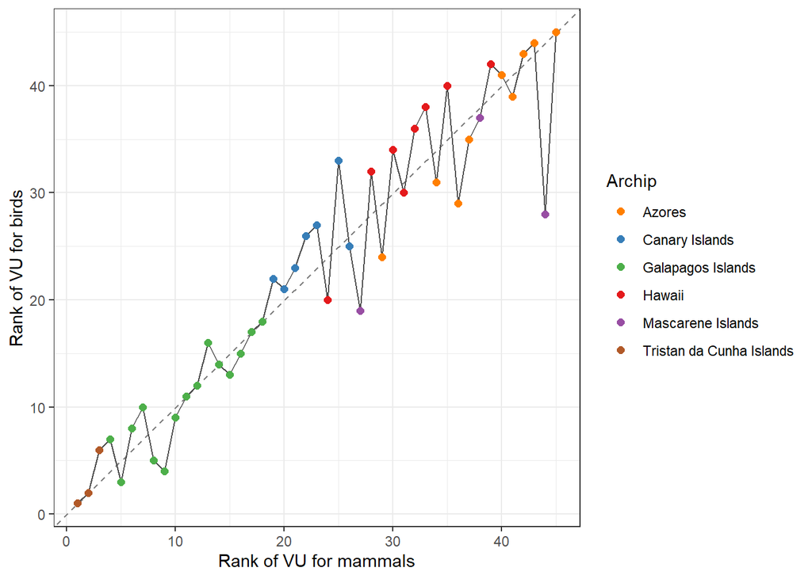

```r
VU_mam_isl <- vulnerabilityFUN(data_all |> dplyr::filter(Class=="Mammalia"), by_island = T)
VU_bird_isl <- vulnerabilityFUN(data_all |> dplyr::filter(Class=="Aves"), by_island = T)

# combine bird and mammal VU by island to compare final ranking
colnames(VU_mam_isl)[-1] <- paste0(colnames(VU_mam_isl)[-1], "_mam")
colnames(VU_bird_isl)[-1] <- paste0(colnames(VU_bird_isl)[-1], "_bird")
comp_BM <- dplyr::left_join(VU_mam_isl, VU_bird_isl, by = "ID") |>
  # add archipelago information
  dplyr::left_join(data_all|> dplyr::distinct(ID, Archip), by = "ID")

# plot the rankings for both groups
ggplot(comp_BM)+
  geom_abline(slope = 1, intercept = 0, col="grey50", lty = 2)+
  geom_line(aes(x= VU_rank_mam, y = VU_rank_bird), col = "grey30")+
  geom_point(aes(x= VU_rank_mam, y = VU_rank_bird, color = Archip), size = 2)+
  scale_color_manual(values = archip_col)+
  xlab("Rank of VU for mammals")+
  ylab("Rank of VU for birds") + theme_bw()
```

The final ranking is quite similar between the groups, but Hawai’i and Canary islands have a higher VU ranking for birds than for mammals, while Mascarene islands are ranked more vulnerable for mammals than for birds.

## Plot results for VU

### Distribution of VU values within each island

```r
# join VU data with island information
VU_sp_isl_info <- dplyr::left_join(
  isl |> sf::st_drop_geometry() |> dplyr::select(ID, Archip, Island),
  VU_sp_isl
)
```

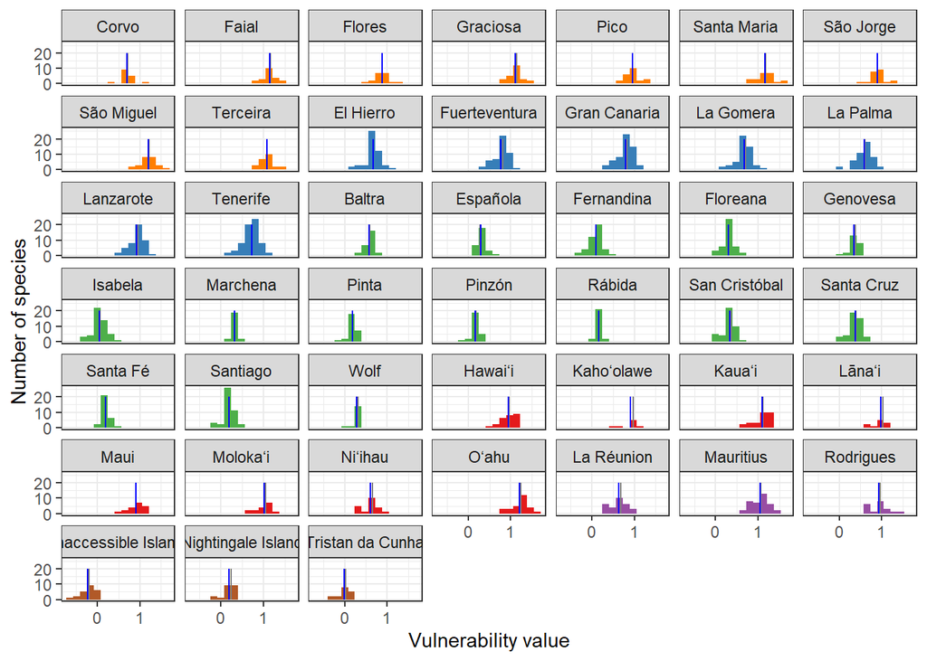

```r
# create a ranking to make sure islands of each archipelago are together in the graph
arch_isl <- paste0(isl$Archip, isl$Island)
archip_order <- isl$Island[match(sort(arch_isl), arch_isl)] |> unique()
VU_sp_isl_info$Island <- factor(VU_sp_isl_info$Island, levels = archip_order)

# calculate mean, median and sd value per island
VU_median_mean <-
  VU_sp_isl_info |>
  dplyr::group_by(Archip, Island) |>
  dplyr::summarise(
    Median = median(VU),
    Mean = mean(VU),
    SD = sd(VU)) |> dplyr::ungroup()
isl_order <- VU_median_mean$Island[match(sort(VU_median_mean$Mean), VU_median_mean$Mean)]
VU_median_mean$Island_order <- factor(VU_median_mean$Island, levels = isl_order)
VU_sp_isl_info$Island_order <- factor(VU_sp_isl_info$Island, levels = isl_order)


# plot distribution of VU values within each island
ggplot(VU_sp_isl_info, aes(VU)) +
  geom_histogram(aes(fill=Archip), col= NA, bins = 15) +
  scale_fill_manual(values = archip_col) +
  facet_wrap(~Island) +
  geom_segment(data=VU_median_mean,
               aes(x = Median, xend=Median, y=0, yend=20), col='grey50') +
  geom_segment(data=VU_median_mean,
               aes(x = Mean, xend=Mean, y=0, yend=20), col='blue') +
  theme_bw() + ylab("Number of species")+ xlab("Vulnerability value")+
  theme(legend.position = "none")
```

**Supplementary figure XX.** Distribution of vulnerability values for all species in each islands, colored by archipelago. Blue and grey bars represent the mean and the median values of the distribution, respectively.

To show these in an aggregated manner, we can plot each island as a row, rank the islands bu VU value, and still plot the species variability with lighter grey dots.

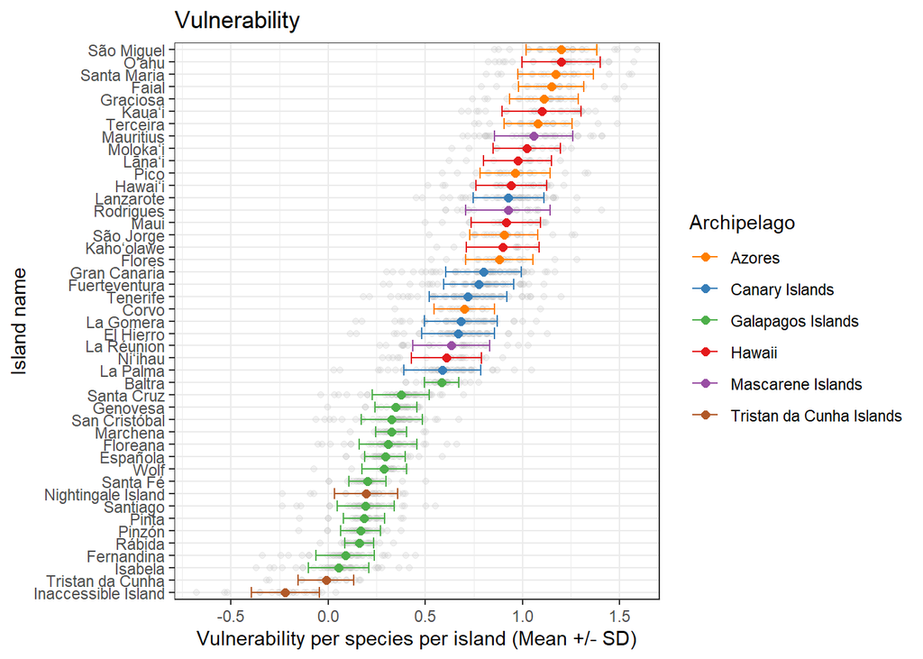

**Figure XX.** Final vulnerability of the 45 islands from the six archipelagos for birds and mammals. Each raw represents an island, colors depict archipelagos and islands are ordered in decreasing order of vulnerability. Colored points and associated error bars represent the mean and the standard deviation of the VU of each island assemblage. Grey points represent individual values of VU per species per island.

### Map VU across archipelagos

The final figure will be done with the position of each archipelago on a global map, this is just to give a first idea of the spatial variation per archipelago.

Global map

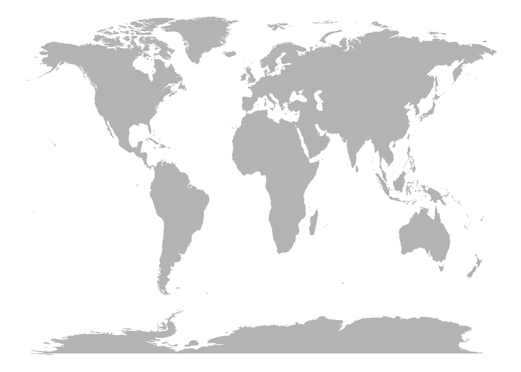

Add the archipelagos

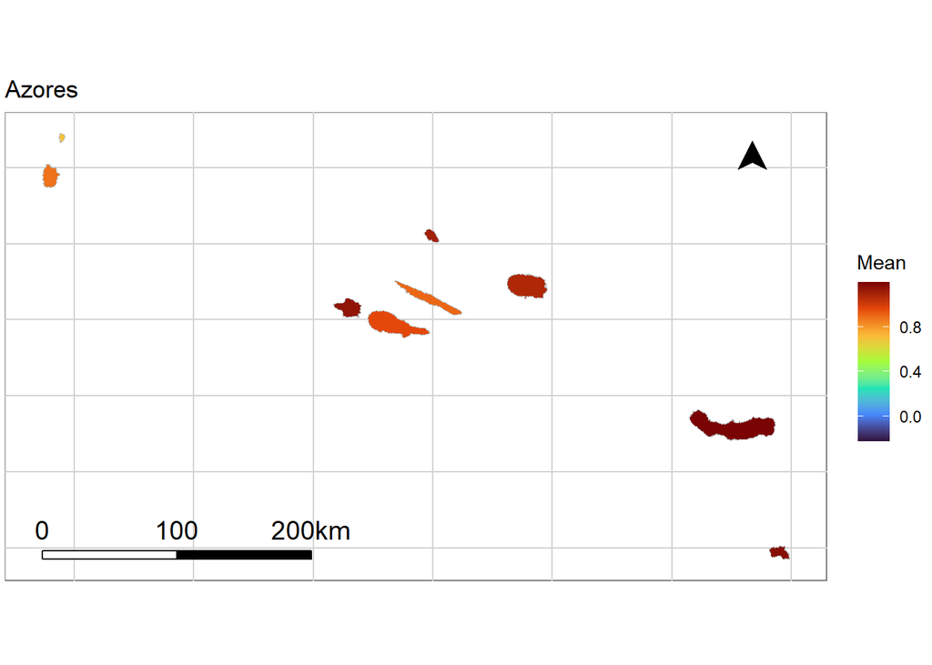

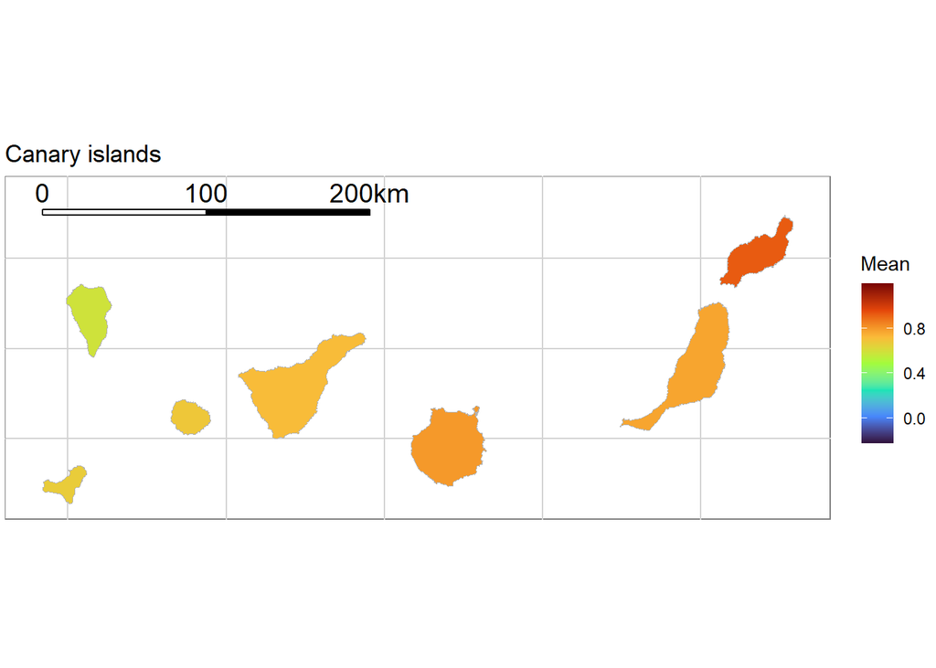

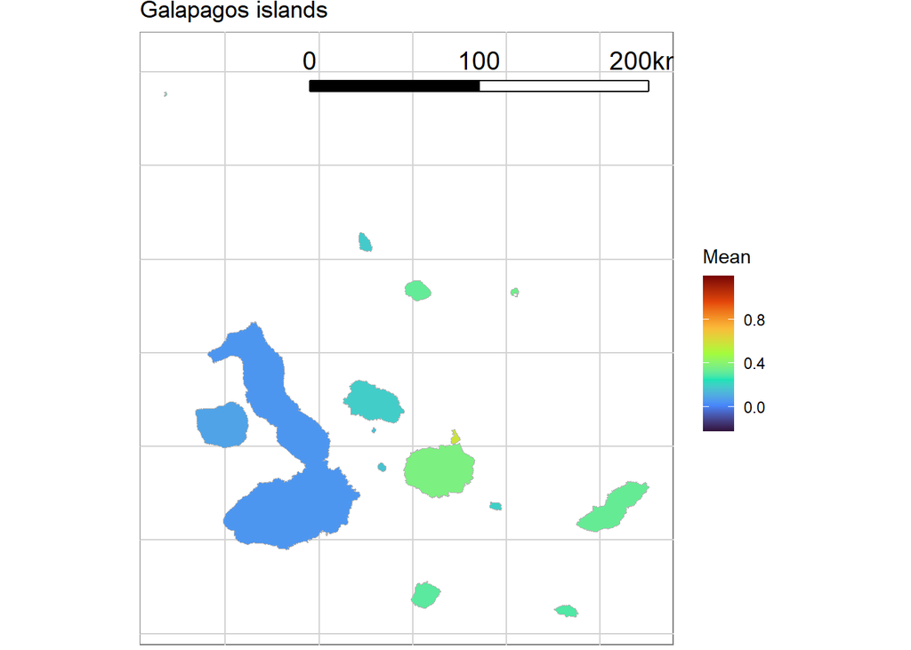

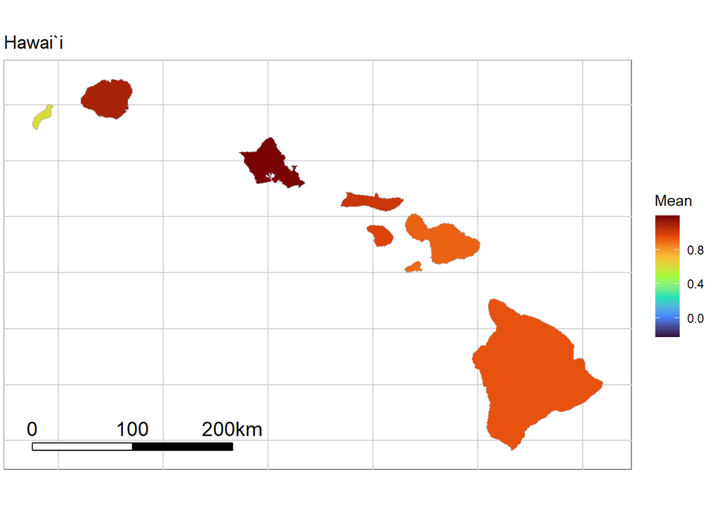

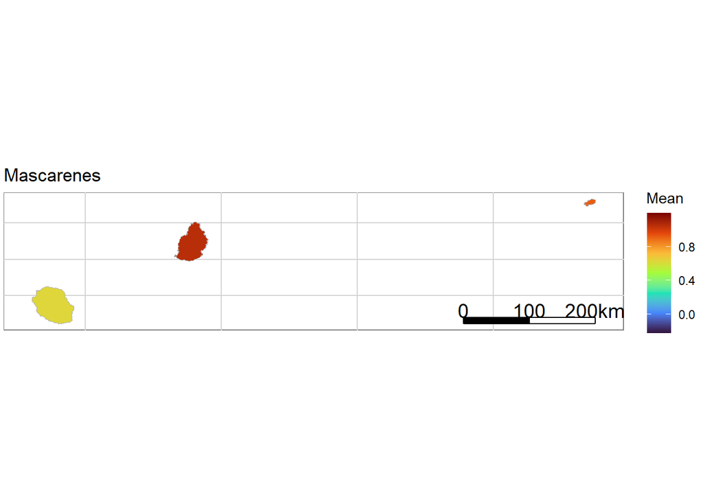

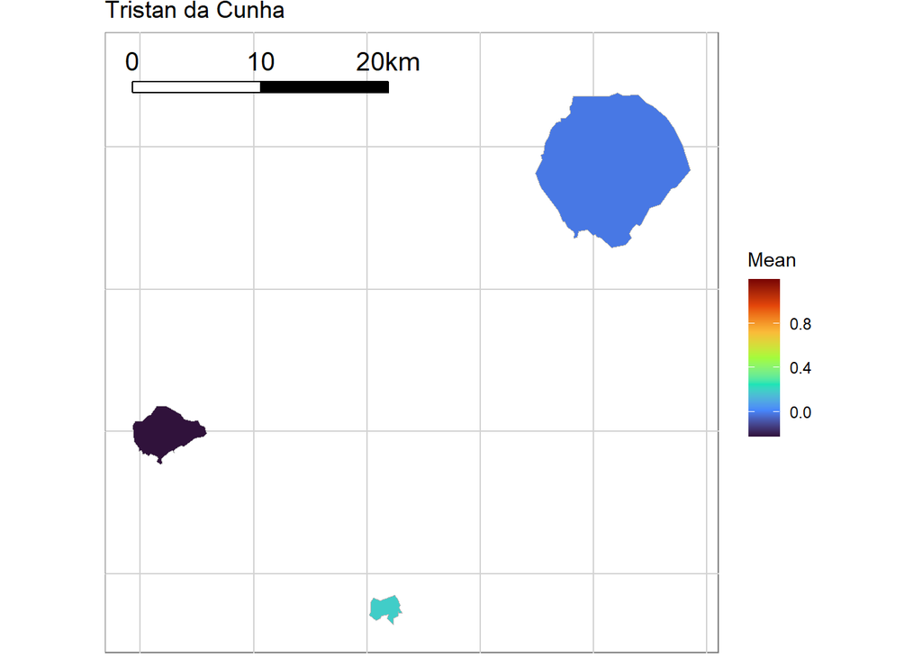

Check the relationship between VU and latitude/ longitude

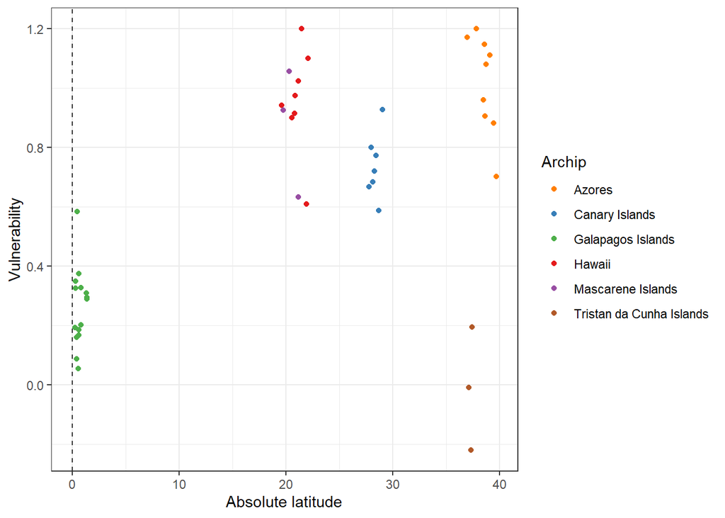

```r
ggplot(shp_vu)+
  geom_vline(xintercept = 0, color = "grey20", lty=2)+
  geom_point(aes(x=abs(Lat), y = Mean, col = Archip))+
  scale_color_manual(values = archip_col)+
  theme_bw()+ xlab("Absolute latitude") + ylab("Vulnerability")
```

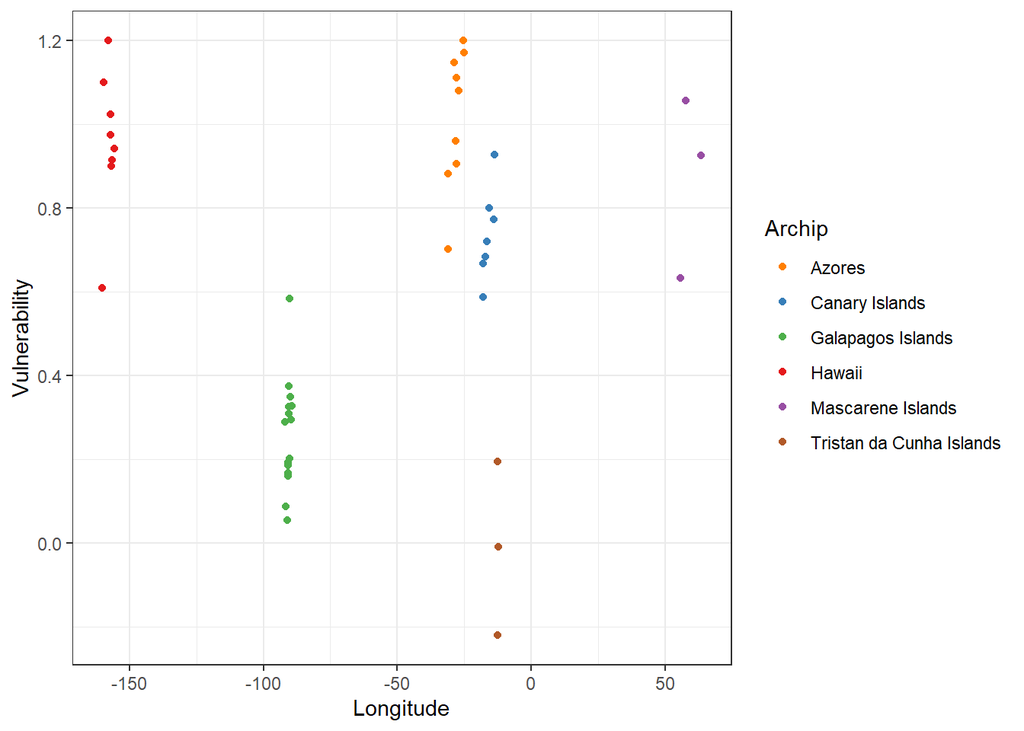

```r
ggplot(shp_vu)+
  #geom_vline(xintercept = 0, color = "grey20", lty=2)+
  geom_point(aes(x=Long, y = Mean, col = Archip))+
  scale_color_manual(values = archip_col)+
  theme_bw()+ xlab("Longitude") + ylab("Vulnerability")
```

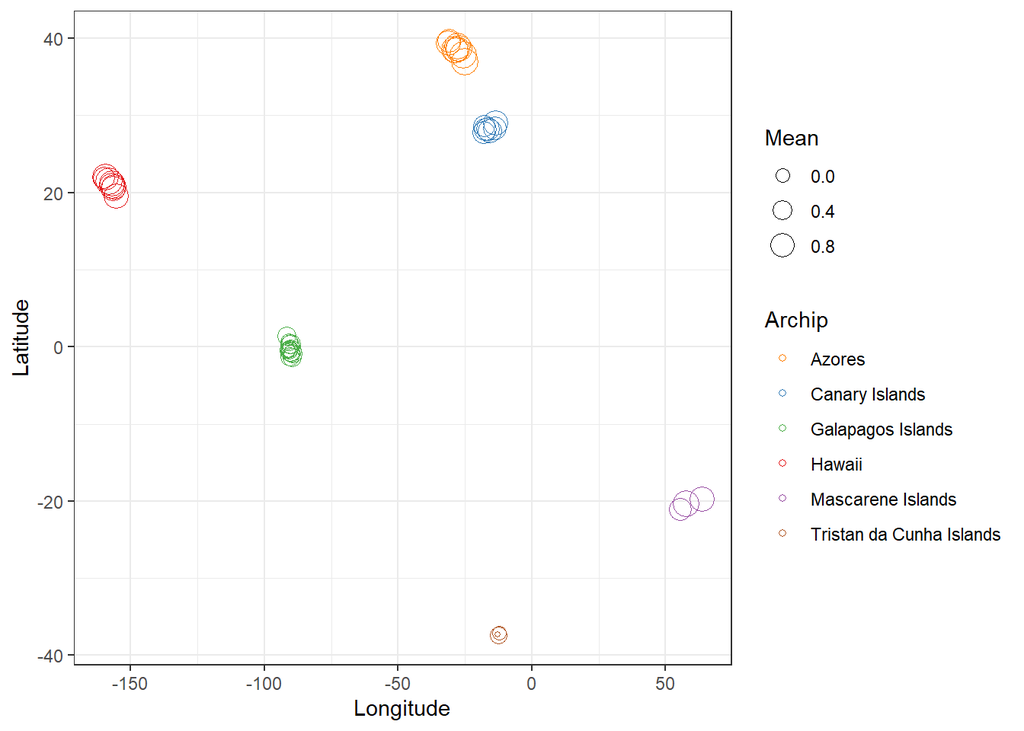

```r
ggplot(shp_vu)+
  #geom_vline(xintercept = 0, color = "grey20", lty=2)+
  geom_point(aes(x=Long, y = Lat, col = Archip, size = Mean), shape = 1)+
  scale_color_manual(values = archip_col)+
  theme_bw()+ xlab("Longitude") + ylab("Latitude")
```

# Calculate E, S, and AC

## Exposure

Exposure is calculated at the island level. The output contains:

- island identifier ( *ID* column)
- normalized markers for each threat;
- normalized LU, CC, or IAS threat (LU = mean_HM_change + rdens_osm; CC = sed_tot_med; IAS = nb_alien + alien_vert_cover);
- final exposure (E = LU + CC + IAS), also normalized between 0 and 1.

```r
# get exposure
E_all <- exposureFUN(data_all)
head(E_all)
```

```
##    mean_HM_change  rdens_osm sed_tot_med nb_alien alien_vert_cover          lu
## 1      0.09684635 0.06039705  0.01336898 0.000000       0.00000000 0.042467769
## 22     0.09701472 0.00000000  0.02009707 0.000000       0.00000000 0.006688567
## 45     0.09661363 0.03924675  0.06037080 0.078125       0.01069444 0.029765057
## 62     0.15208758 0.11372950  1.00000000 1.000000       0.36384756 0.106966594
## 88     0.04490748 0.04084808  0.73244762 0.250000       0.10888882 0.000000000
## 96     0.09842186 0.21767582  0.60512533 0.515625       0.22653919 0.136836073
##            cc        ias   exposure   ID
## 1  0.01336898 0.00000000 0.02543611 7725
## 22 0.02009707 0.00000000 0.01049995 7731
## 45 0.06037080 0.05301643 0.07032794 7733
## 62 1.00000000 0.81408223 0.98440402 9827
## 88 0.73244762 0.21422116 0.48344265 9829
## 96 0.60512533 0.44299868 0.60595618 9832
```

### Relationships between exposure components

#### Correlation between threat markers

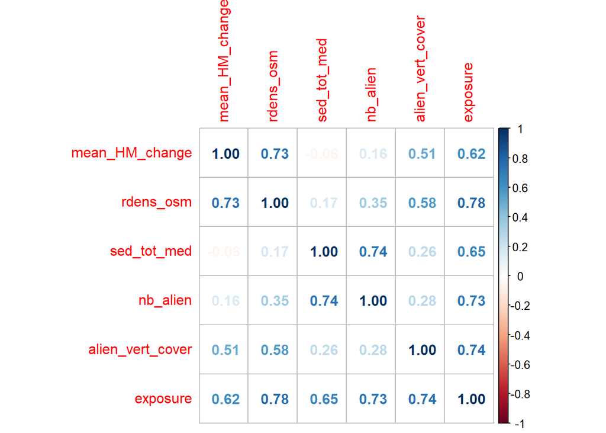

```r
E_markers_corr <- cor(E_all |> dplyr::select(-c(ID, lu, cc, ias)))
corrplot::corrplot(E_markers_corr, method = "number")
```

At first sight, all markers contribute quite evenly to final exposure. The two markers of LU are positively correlated between each other, and also positively correlated with the percentage of alien vertebrate coverage. Climate change marker (which is the combination of precipitation and temperature change but computed following Williams et al (2007), thus aggregated together) is positively correlated with the number of alien species.

#### Correlation between threats and final exposure

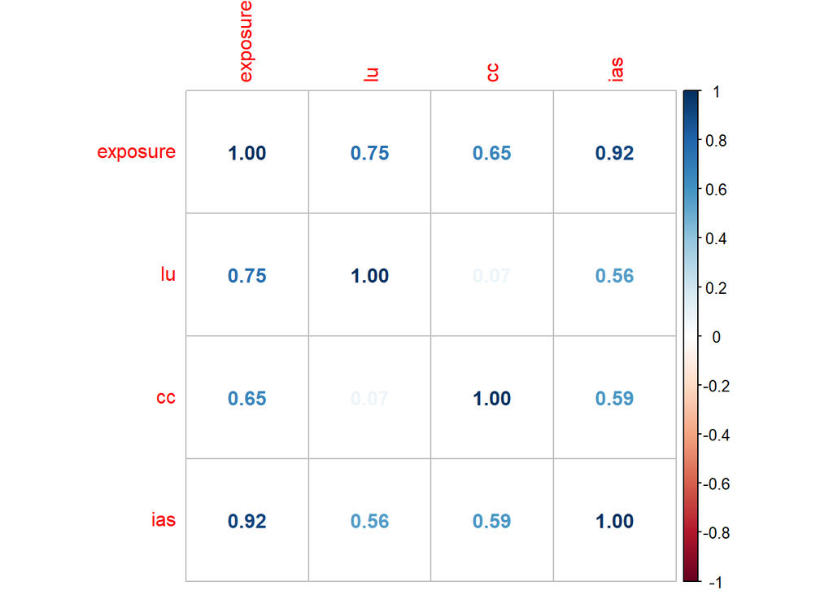

```r
E_all_corr <- cor(E_all[,c("exposure", "lu", "cc", "ias")])
corrplot::corrplot(E_all_corr, method = "number")
```

Final exposure is positively linked to all threats, but super correlated with IAS threat. Possibly because this threat has many low values but also many intermediate to high values, in contrast with CC an LU that have both a distribution with many low values but few with intermediate to high. Can be visualized with histograms:

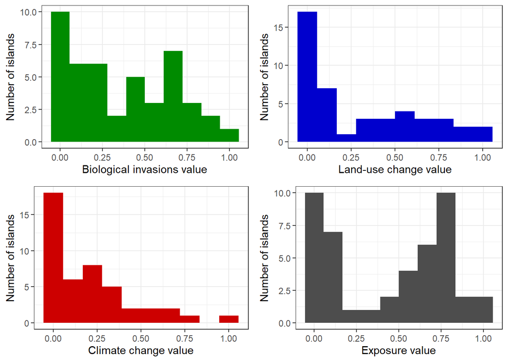

### Potential figure for the paper: relationships between threats

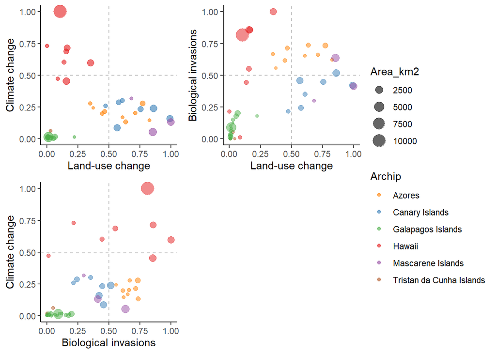

**Figure X.** Relationship between exposure components: climate change, land-use change, and biological invasions.

We still observe the fact that across this archipelagos, no islands are highly exposed to both CC and LUC. However, biological invasions are positively associated with the two other threats. We also notice a strong archipelago effect for climate change (expected given that islands from an archipelago have similar climatic conditions), although Hawai`i islands have broader differences than other archipelagos in CC exposure. For LUC, half of the archipelagos have very similar values (Galapagos, Hawaii, Tristan da Cunha) whereas the others harbor a large range of LUC values (Canary, Azores, Mascarenes), with islands poorly vs. highly exposed to LUC. For biological invasions, except for Tristan da Cunha (very small values), all archipelagos have a wide range of values, even Galapagos, which makes the islands different from each other in final exposure, even within an archipelago.

## Sensitivity

Sensitivity is calculated at the species level. The output contains:

- species identifier ( *sci_name*);
- 4 normalized traits
- final sensitivity (S = gen_length_y + (1-AoH_km2) + (1-nb_diet) + (1-nb_hab)), also normalized between 0 and 1.

Some traits are inversely correlated with their sensitivity, this needs to be set using the argument `inv_variables`. For example, size of AoH (km²) is used to calculate sensitivity, but the larger the AoH, the smaller the sensitivity.

```r
# get sensitivity
S_all <- sensitivityFUN(data_all,
                        sens_cols = c("aoh_km2", "nb_diet", "nb_hab", "gen_length_y"),
                        inv_variables = c("aoh_km2", "nb_hab", "nb_diet"),
                        sp_col_name = "sci_name",
                        isl_col_name = "ID",
                        norm = "minmax")
head(S_all)
```

```
##     aoh_km2   nb_diet    nb_hab gen_length_y sensitivity
## 1 0.4799371 0.8571429 0.6666667    0.3214121   0.4562675
## 2 0.9016708 0.8571429 0.6666667    0.3695843   0.7048089
## 3 0.9248081 0.8571429 0.7777778    0.3613334   0.7714512
## 4 0.9295002 0.8571429 0.6666667    0.2474481   0.6549284
## 5 0.9999990 0.7142857 0.6666667    0.4333307   0.7149734
## 6 0.7141035 0.8571429 0.5555556    0.5486541   0.6415458
##                   sci_name
## 1         Mirounga leonina
## 2 Arctocephalus tropicalis
## 3           Anous stolidus
## 4  Aphrodroma brevirostris
## 5           Ardenna gravis
## 6    Catharacta antarctica
```

Relationship between Sensitivity markers

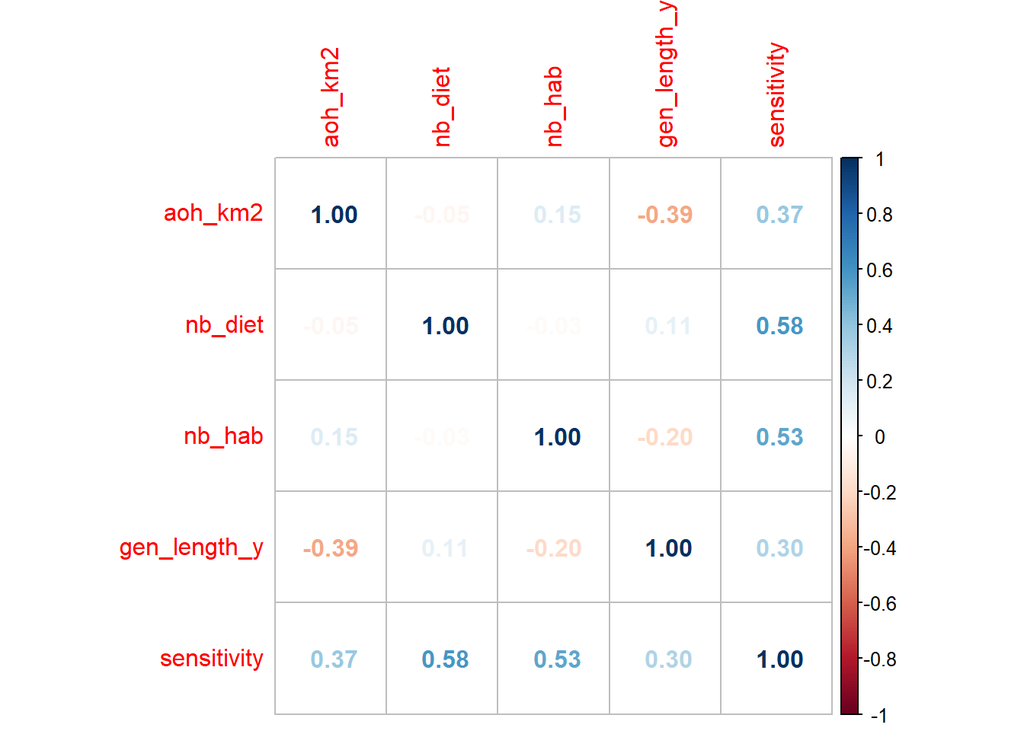

```r
S_markers_corr <- cor(S_all |> dplyr::select(-sci_name))
corrplot::corrplot(S_markers_corr, method = "number")
```

## Adaptive capacity

Adaptive capacity is calculated at the species per island level. The output contains:

- the island identifier ( *ID* );
- species identifier ( *sci_name*);
- normalized abiotic components and the functional redundancy (at the island level);
- normalized trait for species dispersal;
- normalized intermediate components of AC:
  - AC_biotic = dispersal + fred;
  - AC_abiotic = Area + max_elev + mean_tri + PA_prop;
- final AC (AC = AC_biotic + AC_abiotic), normalized between 0 and 1.

```r
# get AC
AC_all <- adaptive_capacityFUN(data_all)
head(AC_all)
```

```
##     ID                 sci_name dispersal         Area  max_elev  mean_tri
## 1 7725         Mirounga leonina 1.0000000 0.0001173038 0.0577853 0.8334763
## 2 7725 Arctocephalus tropicalis 0.7627537 0.0001173038 0.0577853 0.8334763
## 3 7725           Anous stolidus 0.8710125 0.0001173038 0.0577853 0.8334763
## 4 7725  Aphrodroma brevirostris 0.8502080 0.0001173038 0.0577853 0.8334763
## 5 7725           Ardenna gravis 0.8557559 0.0001173038 0.0577853 0.8334763
## 6 7725    Catharacta antarctica 0.6768377 0.0001173038 0.0577853 0.8334763
##   PA_prop      fred ac_abiotic ac_biotic adaptive_capacity
## 1       0 0.5729167  0.2980223 0.7864583         0.5718575
## 2       0 0.5729167  0.2980223 0.6678352         0.4992691
## 3       0 0.5729167  0.2980223 0.7219646         0.5323922
## 4       0 0.5729167  0.2980223 0.7115624         0.5260268
## 5       0 0.5729167  0.2980223 0.7143363         0.5277243
## 6       0 0.5729167  0.2980223 0.6248772         0.4729820
```

Relationships between AC markers

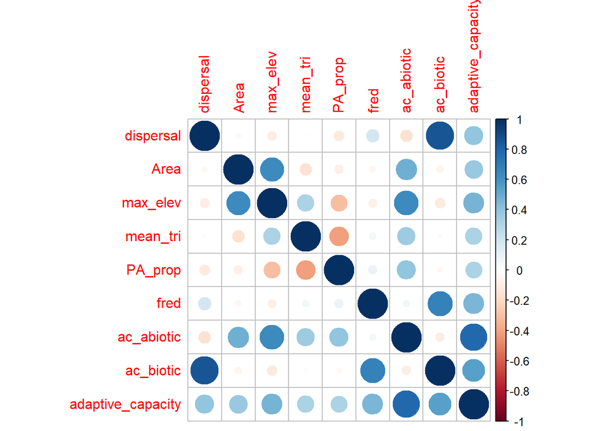

```r
AC_markers_corr <- cor(AC_all |> dplyr::select(-c(sci_name, ID)))
corrplot::corrplot(AC_markers_corr, method = "circle")
```

## Parallel plots of components

As birds and mammals are grouped for the final vulnerability, we can plot only one map (and possibly put in Supplementary the plot for birds only and mammals only).

### Create the data frame

We need a data frame with one value per island for each metric, and the final VU to color the lines. Thus, we aggregated all metrics as the mean of all species on each island. Note that for markers at the island level, it is equivalent to the raw value.

```r
metrics <- VU_sp_isl_info |> dplyr::select(ID, Archip, sci_name, VU) |>
  # add exposure metrics
  dplyr::left_join(E_all |> dplyr::select(ID, mean_HM_change:alien_vert_cover), by ="ID") |>
  # add sensitivity metrics
  dplyr::left_join(S_all |> # invert the 'generalist' variables to 'specialist' ones
                     dplyr::mutate(AoH_specialist = 1-aoh_km2,
                                   Diet_specialist = 1-nb_diet,
                                   Habitat_specialist = 1-nb_hab)|>
                     dplyr::select(sci_name, gen_length_y, AoH_specialist:Habitat_specialist),
                   by ="sci_name") |>
  # add ac metrics
  dplyr::left_join(AC_all |> dplyr::select(ID, sci_name, dispersal, fred, Area, max_elev, mean_tri, PA_prop),
                   by =c("ID", "sci_name")) |>
  dplyr::group_by(Archip, ID) |>
  dplyr::summarise_if(is.numeric, mean) |> dplyr::ungroup()
```

### Parallel coordinate plot

Each island is represented by a line, with points representing the value of each individual metric.

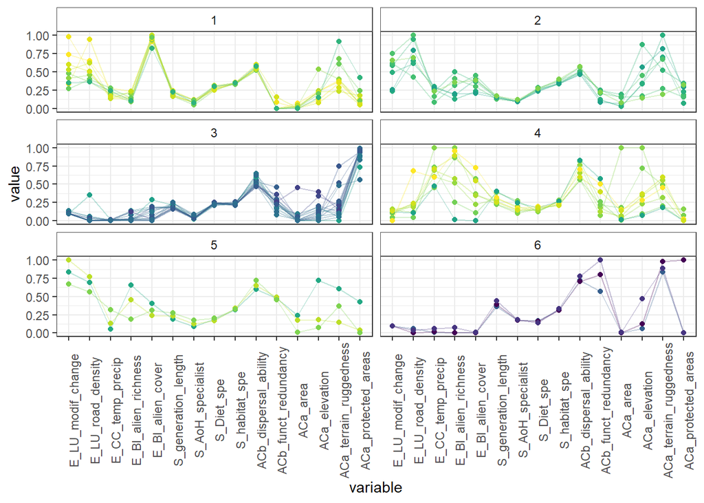